# WNBA Salaries

```r
###LIZ: there are a lot more of them, but US players make more.
```

8. How does salary relate to performance (field goal percentage)? **LIZ: another example of doing a gut-check scatterplot to see if there’s relationship that we should explore further (under the guidance of a statistician)**

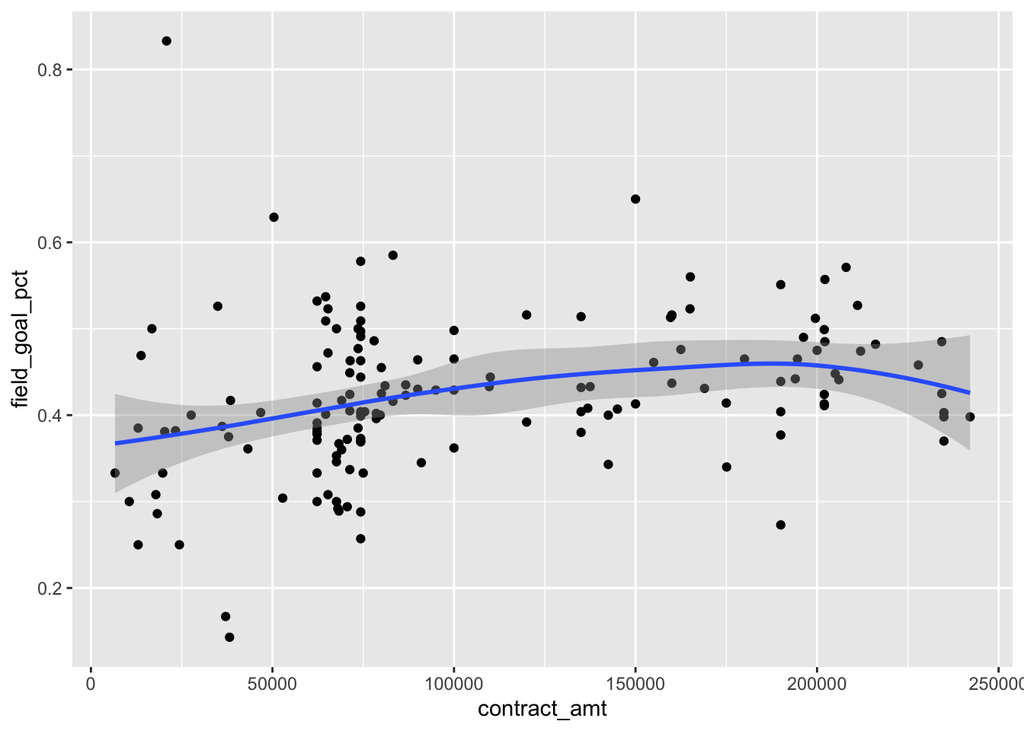

```r
teams %>%
  inner_join(salaries, by = c("player_name"="name")) %>%
  filter(contract_amt > 0 & field_goal_pct > 0) %>%
  ggplot(aes(x = contract_amt, y = field_goal_pct)) +
  geom_point() +
  geom_smooth()
```

```r
###LIZ: it does look like better paid players have slightly higher field goal percentages.
```

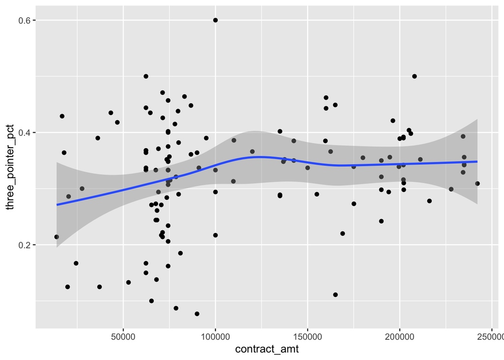

```r
teams %>%
  inner_join(salaries, by = c("player_name"="name")) %>%
  filter(contract_amt > 0 & three_pointer_pct > 0) %>%
  ggplot(aes(x = contract_amt, y = three_pointer_pct)) +
  geom_point() +
  geom_smooth()
```

```r
###LIZ: maaaaybe? Doesn't look like a strong relationship to me. Remember that there are some lurking variables in here, such as playing time!
```

10. Which team fouls the most on average? **LIZ: this calls for grouping by team and summing up fouls**

```r
teams %>%
  inner_join(salaries, by = c("player_name"="name")) %>%
  group_by(team) %>%
  summarise(total_fouls = sum(fouls, na.rm=T)) %>%
  arrange(desc(total_fouls))
```

| team | total_fouls |
| --- | --- |
| Los Angeles Sparks | 24.2 |
| Connecticut Sun | 23.1 |
| Washington Mystics | 22.4 |
| Indiana Fever | 22.2 |
| Chicago Sky | 22.0 |
| Phoenix Mercury | 21.9 |
| Atlanta Dream | 21.4 |
| Dallas Wings | 20.5 |
| Minnesota Lynx | 19.9 |
| Seattle Storm | 19.9 |

[output cut: 3 more lines]

```r
###LIZ: the Sparks have the most fouls per game, on average.
```

11. Which colleges produce the players that foul the most and the least? **LIZ: very similar to the last question, we’ll change the variable we are grouping by, but we also have to change our summary function. In comparing teams, we know they all play about the same number of games, but that’s not true of colleges. For this comparison we’ll look at average and median fouls:**

```r
teams %>%
  inner_join(salaries, by = c("player_name"="name")) %>%
  group_by(college) %>%
  summarise(players = n(),
            avg_fouls = mean(fouls, na.rm=T),
            med_fouls = median(fouls, na.rm=T)) %>%
  arrange(desc(avg_fouls))
```

| college | players | avg_fouls | med_fouls |
| --- | --- | --- | --- |
| Florida State | 1 | 3.6000000 | 3.60 |
| Melbourne | 1 | 3.2000000 | 3.20 |
| Missouri | 1 | 3.2000000 | 3.20 |
| Syracuse | 1 | 2.9000000 | 2.90 |
| George Washington | 1 | 2.8000000 | 2.80 |
| Kentucky | 1 | 2.8000000 | 2.80 |
| Stanford | 6 | 2.7166667 | 2.70 |
| St. Joseph's (PA) | 1 | 2.6000000 | 2.60 |
| Texas-Austin | 1 | 2.6000000 | 2.60 |
| Mississippi State | 2 | 2.6000000 | 2.60 |

[output cut: 52 more lines]

```r
###LIZ: Again we run into the fact that many colleges (including Mizzou) have only one alum in the league. So it's not really fair to base a whole college analysis on one player. These college comparisons would be better with more years of data.
```

12. Which players / teams are the best defensively? (looking at defensive rebounds, blocks and steals) **LIZ: We’ll start with teams, which will require a group by and summarizing. Looking at players, we can just sort the data by those defensive categories since one row is one player.**

```r
teams %>%
  inner_join(salaries, by = c("player_name"="name")) %>%
  group_by(team) %>%
  summarise(players = n(),
            all_Drebounds = sum(defensive_rebounds,na.rm=T),
            all_blocks = sum(blocks, na.rm=T),
            all_steals = sum(steals, na.rm=T)) %>%
  arrange(desc(all_Drebounds))
```

| team | players | all_Drebounds | all_blocks | all_steals |
| --- | --- | --- | --- | --- |
| Washington Mystics | 11 | 33.4 | 4.3 | 9.2 |
| Las Vegas Aces | 12 | 32.4 | 5.3 | 9.3 |
| Los Angeles Sparks | 14 | 31.9 | 3.6 | 11.2 |
| Minnesota Lynx | 12 | 31.6 | 3.0 | 7.2 |
| New York Liberty | 11 | 31.1 | 4.9 | 7.2 |
| Atlanta Dream | 11 | 30.8 | 5.4 | 7.0 |
| Chicago Sky | 12 | 30.5 | 5.3 | 9.1 |
| Connecticut Sun | 11 | 30.4 | 4.5 | 10.1 |
| Seattle Storm | 11 | 30.1 | 5.0 | 8.2 |
| Dallas Wings | 11 | 29.8 | 4.9 | 7.9 |

[output cut: 3 more lines]

```r
###LIZ: something to keep in mind here; it would probably be fairer for a team comparison to get different stats that looked at player performance cumulatively over the whole season, rather than a per game average. If a player only plays a few minutes but has a high field goal percentage, for example, that has the same weight as a player who plays all the time and has the same field goal percentage, even though that second player has a much bigger impact on a team than the player that rarely plays. We're doing math on averages per game, which is not ideal.
```